# Predicting The Next Word

Abhijit Jantre  
28th February,2017

### The Goal

- The goal of this project is to create an algorithm to predict the next word based on the previous word(s) typed by the user.
- I have used 3 databases of english sentences extracted from news, blogs and twitter.
- At first, I built the relationship between words. Then, I employed exploratory analysis to build an n-gram model for predicting the next word based on the previous 1, 2, or 3 words.
- All text mining and natural language processing was done using various R packages.

### The Methodology

- I built a basic n-gram model with the natural language processing (NLP) which can be accessed by clicking on the link

  http://rpubs.com/abhijitjantre/NgramModelWithNaturalLanguageProcessingNLP
- Subsequently, I created R code for predicting the next word.
- I have then created ngram and used it in conjuction with the R code for predicting the next word.
- Finally, I deployed the application on shinywebserver.

  https://abhijitjantre.shinyapps.io/Final/

### User Interface And Application

The user types the word/phrase/text and clicks on the button named 'Submit For Prediction'. Subsequently, three outcomes appear on the right hand panel of the screen namely

- Cleaned Text
- First Best Prediction
- Second Best Prediction

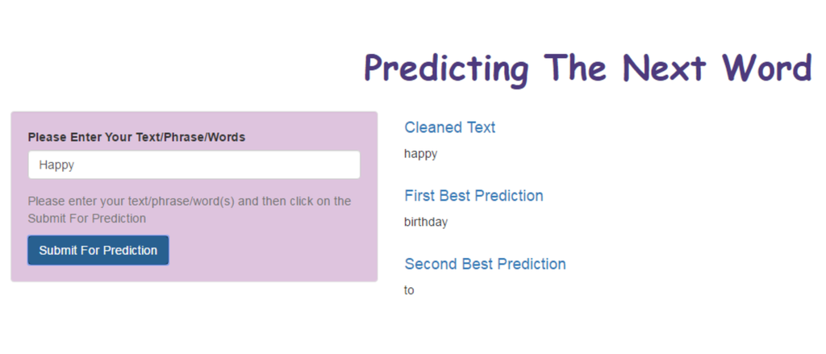

### References And APP Related Publications

**References**

- http://en.wikipedia.org/wiki/N-gram
- https://class.coursera.org/dsscapstone-002

**My App Publications**

- On Shiny Apps : https://abhijitjantre.shinyapps.io/Final/
- Code On Git Hub : https://github.com/abhijitjantre/DataScienceCapstoneProject